# Plotting Moderation Effects With ggplot2

Shu Fai Cheung

2022-09-11

There are some R packages that help researchers to plot moderation (interaction) effects: The linear relations between `x` (independent variable / predictor) and `y` (dependent variable / outcome variable) for two or more levels of `w` (moderator). For example, I have been using [visreg](https://pbreheny.github.io/visreg/) for multiple regression models fitted by `lm()` for a long time. It is simple to use and supports both base R graphics and `ggplot2`. [stdmod](https://sfcheung.github.io/stdmod/index.html), which I maintained, also has the function [plotmod](https://sfcheung.github.io/stdmod/articles/plotmod.html) for plotting simple effects in moderated regression. For structural equation modelling, [semTools](https://github.com/simsem/semTools/wiki) can be used to plot interaction for latent variables using [plotProbe()](https://rdrr.io/cran/semTools/man/plotProbe.html). `plotProbe()` can also be used to on observed variables using this [workaround](https://groups.google.com/g/lavaan/c/h_LHQUFbx0k/m/jmQwRJEqBAAJ).

However, there may be case in which all we need is just two or more lines, and all we have are the simple effects: Two or more sets of intercepts of slopes.

This is how to plot the simple effect:

Write a simple function to compute the points

```r
# Simple regression model
xyline <- function(x, a, b) {a + b * x}
```

Set the range for `x`:

```r
# Range of x
x <- c(0, 10)
```

Compute the predicted values of `y` at the lower and upper limit of the range of `x`, for each level of `w`, when all other predictors of `y` in the model, if any, are equal to zero:

```r
# Generate the two points when moderator = "Low"
dat0 <- data.frame(Moderator = "Low",
                   x = x,
                   y = xyline(x, a = 0, b = 0.5))
# Generate the two points when moderator = "High"
dat1 <- data.frame(Moderator = "High",
                   x = x,
                   y = xyline(x, a = 2, b = 1.0))
```

Combine the datasets:

```r
dat <- rbind(dat0, dat1)
dat
```

```
##   Moderator  x  y
## 1       Low  0  0
## 2       Low 10  5
## 3      High  0  2
## 4      High 10 12
```

Draw the lines using `ggplot2`:

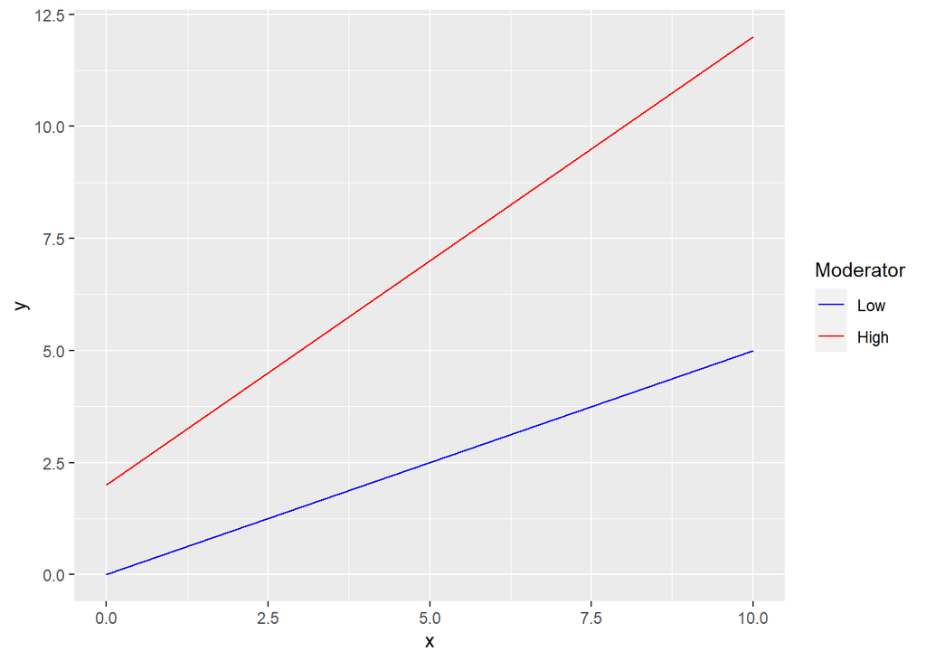

```r
library(ggplot2)
p <- ggplot(dat, aes(x = x, y = y, color = Moderator)) +
            geom_line() +
            scale_color_manual(values = c("Low" = "blue", "High" = "red"))
p
```

This plot can then be modified as necessary:

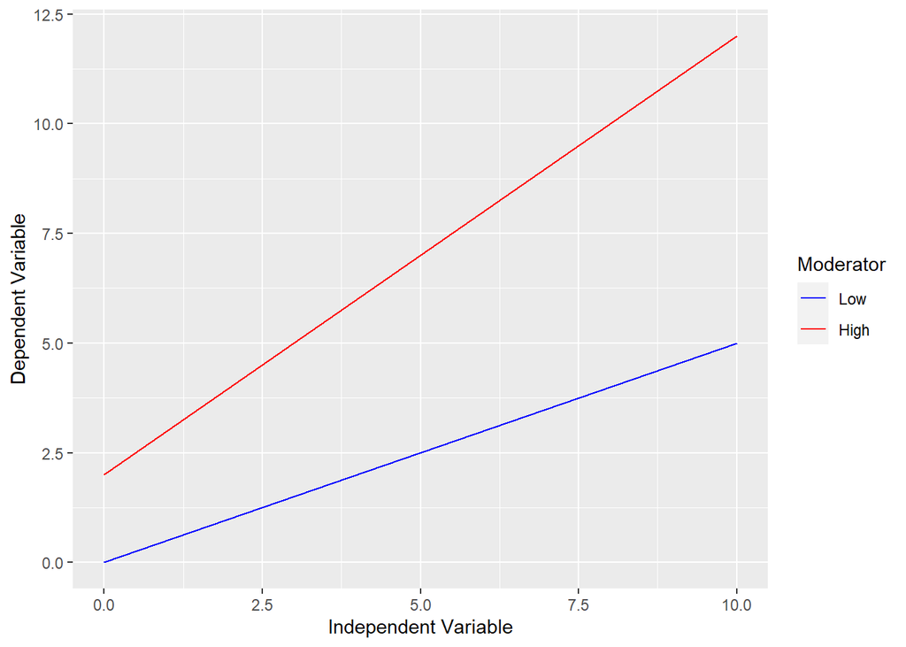

```r
p2 <- p + xlab("Independent Variable") +
          ylab("Dependent Variable")
p2
```

This solution can be used for multiple regression or structural equation modelling.

Though not as elegant as using packages devoted to plotting moderation effects, this solution may be good enough for some simple scenarios. I believe it can be further improved. However, if we want more, maybe it is better to use packages like `semTools` and `visreg`.

P.S.: This post is based on a suggestion I posted to the Google Group for `lavaan`.